# 第1回 課題の答え合わせ

基本TODO①〜④と応用①②③

# 基本TODO

## TODO①：気になる列の例

```
        気温  体感気温
mean  0.50  0.47
std   0.18  0.16
```

- `気温`と`体感気温`は、平均もばらつきもほぼ同じ
- 5節で相関を出すと0.992。中身がほぼ同じ2列

## TODO①：もう1つの癖

```
季節
1    181
2    184
3    188
4    178
```

- `季節`は1〜4の番号。大小に意味のない区分で、4は1の4倍ではない

## TODO②：湿度で描いた例

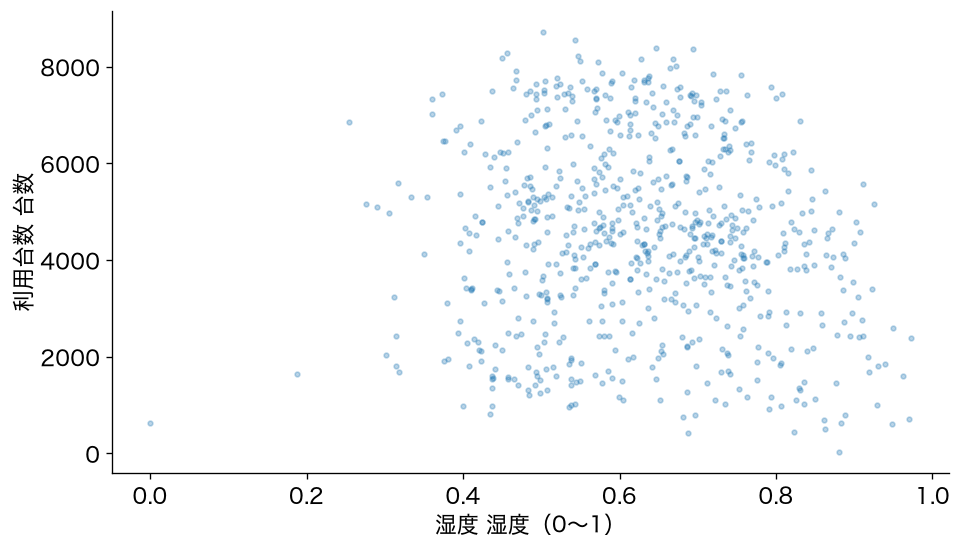

```python
plt.scatter(df['湿度'], df['台数'], s=8, alpha=0.3)
plt.xlabel('湿度 湿度（0〜1）')
plt.ylabel('利用台数 台数')
plt.show()
```

## 湿度と台数は、どんな関係？

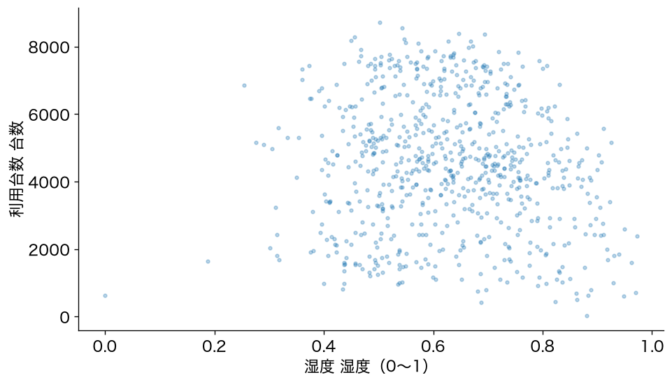

- 気温のような、はっきりした右上がりは見えない

## 右端だけ、少ない

- 湿度0.85以上の46日は、平均2849台。ほかの日より少ない

## 右端は、曇りか雨・雪の日

- その46日は、どれも曇りか雨・雪の日。湿度より天気が関係していそう

## 全体では、相関は弱い

- 湿度と台数の相関は −0.10。右端の少しの日を除けば、ほとんど関係がない

## TODO③：晴れと雨・雪

```python
sunny = df[df['天気'] == 1]
rainy = df[df['天気'] == 3]
print('晴れ   日数:', len(sunny), ' 平均台数:', round(sunny['台数'].mean()))
print('雨・雪 日数:', len(rainy), ' 平均台数:', round(rainy['台数'].mean()))
```

```
晴れ   日数: 463  平均台数: 4877
雨・雪 日数: 21  平均台数: 1803
```

- お手本の条件を、`df['天気'] == 1`と`== 3`に変えて2回使う

## 雨・雪の日は、晴れの日の半分以下

```
晴れ   日数: 463  平均台数: 4877
雨・雪 日数: 21  平均台数: 1803
```

- 晴れ4877台、雨・雪1803台

## でも、雨・雪の日は21日だけ

```
晴れ   日数: 463  平均台数: 4877
雨・雪 日数: 21  平均台数: 1803
```

- 日数が少ないグループの平均は、頼りない。日数も一緒に見る

## TODO④：分け方の例

```python
for keys in [['気温帯', '年', '月'],
             ['気温帯', '年', '季節'],
             ['月', '年', '天気']]:
    print(keys, '→', mae_of(keys), '台')
```

```
['気温帯', '年', '月'] → 614 台
['気温帯', '年', '季節'] → 629 台
['月', '年', '天気'] → 593 台
```

- 決まった正解はない。気温帯×年×天気の665台より小さくできれば十分

## TODO④：どこまで縮む？

```
4 列 → 408 台 ／ 1日だけのグループ 101 個
5 列 → 214 台 ／ 1日だけのグループ 323 個
```

- 5列まで分けると214台。ずいぶん縮む

## 縮むほど、疑う

```
4 列 → 408 台 ／ 1日だけのグループ 101 個
5 列 → 214 台 ／ 1日だけのグループ 323 個
```

- でも、1日だけのグループが323個。自分自身を答えにしている
- 作るのに使った日で採点するかぎり、細かくするほど甘くなる

# 課題

## 応用①：時刻ごとに集計する

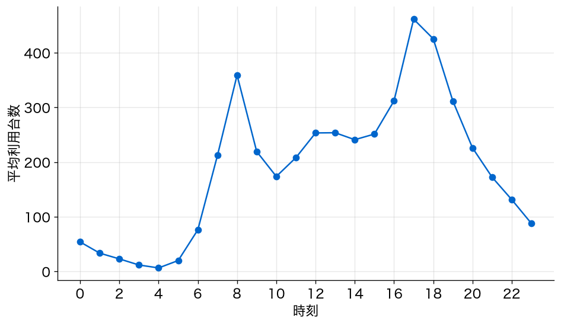

```python
hour = pd.read_csv(f'{DATA_DIR}/bike_hour.csv')
hour = hour.rename(columns=ja_names)        # 1節と同じ前処理
hour = hour.rename(columns={'hr': '時刻'})   # 時間別だけにある列
by_hr = hour.groupby('時刻')['台数'].mean()
by_hr.plot(marker='o', color='#0066cc')
plt.xlabel('時刻'); plt.ylabel('平均利用台数')
plt.xticks(range(0, 24, 2)); plt.grid(alpha=0.3)
plt.show()
```

## 1日の中で、どう変わる？

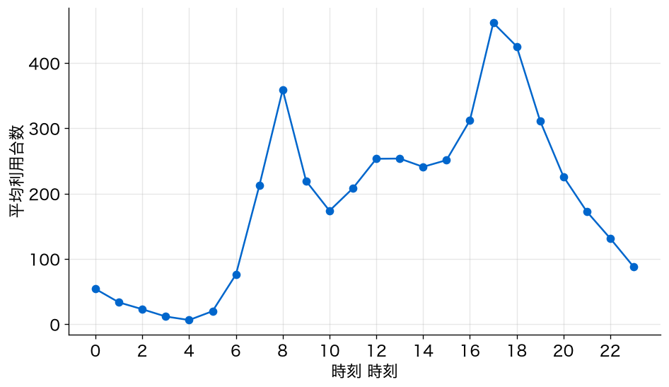

- 横が時刻、縦がその時刻の平均台数

## 山が2つある

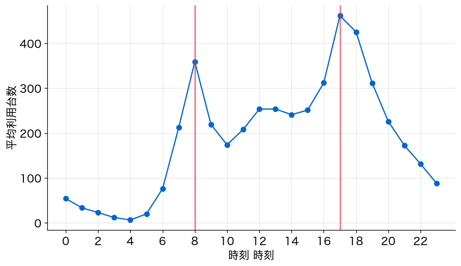

- 朝8時（359台）と、夕方17時（461.5台）。深夜4時は6.4台

## 応用②：最も多い時刻

```python
print('最大の平均台数:', round(by_hr.max(), 1))
print('答え:', int(by_hr.idxmax()))
```

```
最大の平均台数: 461.5
答え: 17
```

- 正答は17。`idxmax()`は、最大値の位置（ここでは時刻）を返す

## 目で見ず、コードで取り出す

```
時刻
16    312.0
17    461.5
18    425.5
```

- 18時（425.5台）とは36台差。グラフを目で見るより、`idxmax()`が確か

## 応用③：模範例

利用は1日の中で一様ではなく、朝8時（平均359台）と夕方17〜18時（約462台・約426台）に2つの山があり、深夜4時は6台まで落ちます。

朝夕の山は通勤・通学の時間帯と重なるので、利用の中心は日常の移動と考えられます。

日次データの合計（1日平均4504台）だけでは見えない「時間帯の偏り」があるので、自転車の配置や整備はこの山に合わせて計画するのがよさそうです。

## 書き方の型

- 1文目：見えた形を、自分の出力の数値で
- 2文目：その形の解釈
- 3文目：相手（運営担当者）にとっての意味

## AIに書かせた文との違い

- 「朝夕に通勤需要がある」の一般論で終わっていないか
- 自分のグラフの数値を根拠にしているか

# まとめ

## まとめと、発展動画へ

- 条件で絞るときは、平均だけでなく日数も見る
- 分けるほど外れ幅は縮むが、縮むほど疑う
- 集計の単位（1日 → 1時間）を変えると、新しい形が見える

発展動画：自動EDAレポート（data-profiling）を、ノートの発展セルで動かします。